# Cyclistic Bike Share Analysis

Jawad028

2024-08-23

## Business Task

The goal is to analyze the differences in how annual members and casual riders use Cyclistic bikes to identify patterns that can inform marketing strategies. The objective is to convert casual riders into annual members by adjusting the membership plans based on their riding behavior. This analysis will provide insights to the stakeholders for targeted marketing campaigns to increase annual memberships.

## Key Stakeholders

- **Lily Moreno**: Director of Marketing
- **Cyclistic Marketing Analytics Team**
- **Cyclistic Executive Team**

## Insights and Business Decisions

1. **Targeted Marketing Campaigns**: Design campaigns that appeal to casual riders, especially those who ride on weekends.
2. **Pricing Strategy**: Consider introducing a membership package tailored for weekend riders.
3. **Digital Media Tactics**: Use data-driven insights to target casual riders with personalized offers.

## Dataset Description

- **ride_id**: Unique identifier for each ride.
- **rideable_type**: Type of bike (e.g., electric, classic).
- **started_at**: Start date and time of the ride.
- **ended_at**: End date and time of the ride.
- **member_casual**: Indicates whether the rider is a member or a casual user.
- Plus additional columns related to station details and coordinates.

## Combinig data from different file

```r
library(tidyverse)
```

```r
file_list <- list.files(path="Dataset",pattern="*.csv",full.names=TRUE)
combined_df <- file_list %>%
  map_dfr(read_csv)
cat("Data Information\n")
```

```
## Data Information
```

```r
print(glimpse(combined_df))
```

```
## Rows: 6,483,343
## Columns: 13
## $ ride_id            <chr> "9340B064F0AEE130", "D1460EE3CE0D8AF8", "DF41BE31B8…
## $ rideable_type      <chr> "electric_bike", "classic_bike", "classic_bike", "e…
## $ started_at         <dttm> 2023-07-23 20:06:14, 2023-07-23 17:05:07, 2023-07-…
## $ ended_at           <dttm> 2023-07-23 20:22:44, 2023-07-23 17:18:37, 2023-07-…
## $ start_station_name <chr> "Kedzie Ave & 110th St", "Western Ave & Walton St",…
## $ start_station_id   <chr> "20204", "KA1504000103", "KA1504000103", "13155", "…
## $ end_station_name   <chr> "Public Rack - Racine Ave & 109th Pl", "Milwaukee A…
## $ end_station_id     <chr> "877", "13033", "TA1305000041", "TA1305000032", "TA…
## $ start_lat          <dbl> 41.69241, 41.89842, 41.89842, 41.88411, 41.96709, 4…
## $ start_lng          <dbl> -87.70091, -87.68660, -87.68660, -87.65694, -87.667…
## $ end_lat            <dbl> 41.69483, 41.89158, 41.90940, 41.88275, 41.96398, 4…
## $ end_lng            <dbl> -87.65304, -87.64838, -87.67769, -87.64119, -87.638…
## $ member_casual      <chr> "member", "member", "member", "member", "member", "…
```

[output cut: 17 more lines]

```r
cat("\nNull Values:\n")
```

```
##
## Null Values:
```

```r
print(summarise_all(combined_df,~sum(is.na(.))))
```

```
## # A tibble: 1 × 13
##   ride_id rideable_type started_at ended_at start_station_name start_station_id
##     <int>         <int>      <int>    <int>              <int>            <int>
## 1       0             0          0        0            1069968          1069968
## # ℹ 7 more variables: end_station_name <int>, end_station_id <int>,
## #   start_lat <int>, start_lng <int>, end_lat <int>, end_lng <int>,
## #   member_casual <int>
```

## Dropping null values and saving data as new csv

```r
cleaned_df <- combined_df %>%
  drop_na()
write_csv(cleaned_df,"cyclistic-0723-0724_cleaned.csv")
```

## Process creating new columns

### I have made a mistake while combining the data some datasets have values of started_at ended_at in mileseconds but others have only seconds that why when we use difftime some rows return seconds as double that give error in sprintf we use as.interger

```r
cleaned_df <- cleaned_df %>%
  mutate(
    ride_length_seconds = as.numeric(difftime(ended_at, started_at, units = "secs")),
    ride_length = seconds_to_period(ride_length_seconds),
    ride_length = sprintf("%02d:%02d:%02d", hour(ride_length), minute(ride_length), as.integer(second(ride_length))),
    week_day = wday(started_at, label = TRUE)
  )
```

### Checking and removing negative values

```r
negative_rides <- cleaned_df %>% filter(ride_length_seconds < 0)
print(negative_rides)
```

```
## # A tibble: 69 × 16
##    ride_id          rideable_type started_at          ended_at
##    <chr>            <chr>         <dttm>              <dttm>
##  1 09632A75482D0DEE electric_bike 2023-07-30 01:21:48 2023-07-30 01:21:44
##  2 CE965D382AED6196 electric_bike 2023-07-20 12:54:28 2023-07-20 12:54:27
##  3 68912B520CB9541C electric_bike 2023-07-20 11:04:45 2023-07-20 11:04:44
##  4 88C6795EB8654AF5 electric_bike 2023-08-19 03:01:47 2023-08-19 03:00:12
##  5 197D33FAF6396DDC electric_bike 2023-08-18 16:01:29 2023-08-18 16:01:28
##  6 82B071A054A869E0 electric_bike 2023-08-19 16:19:27 2023-08-19 16:19:25
##  7 B4C9ECBF117035CD classic_bike  2023-08-12 15:26:17 2023-08-12 15:14:41
##  8 04F78532F71A60CB electric_bike 2023-08-12 13:20:58 2023-08-12 13:18:59
##  9 A46983F7A2B5C09D electric_bike 2023-08-30 16:28:09 2023-08-30 16:28:08
## 10 BA2B853114788016 electric_bike 2023-08-23 17:19:15 2023-08-23 17:19:14
## # ℹ 59 more rows
## # ℹ 12 more variables: start_station_name <chr>, start_station_id <chr>,
## #   end_station_name <chr>, end_station_id <chr>, start_lat <dbl>,
## #   start_lng <dbl>, end_lat <dbl>, end_lng <dbl>, member_casual <chr>,
## #   ride_length_seconds <dbl>, ride_length <chr>, week_day <ord>
```

```r
# Remove negative ride lengths
cleaned_df <- cleaned_df %>% filter(ride_length_seconds >= 0)
```

## Checking Outliers

### This step should be performed at this point but I find out outliers while making box plot that how I know the threshold should be 2000

```r
threshold_minutes <- 2000
threshold_seconds <- threshold_minutes * 60  # 2000 minutes * 60 = 120,000 seconds

# Identify rides longer than 2000 minutes
long_rides <- cleaned_df %>%
  filter(ride_length_seconds > threshold_seconds)

long_rides
```

```
## # A tibble: 4 × 16
##   ride_id          rideable_type started_at          ended_at
##   <chr>            <chr>         <dttm>              <dttm>
## 1 280CB8109510E280 docked_bike   2023-07-06 21:34:55 2023-07-08 14:32:46
## 2 4031082BC503CC84 docked_bike   2023-08-02 17:28:57 2023-08-06 11:07:57
## 3 D2273A0F45CDD4CC docked_bike   2023-08-18 09:13:48 2023-08-20 16:14:38
## 4 47158A16C754A9F4 docked_bike   2023-08-10 22:17:49 2023-08-15 17:09:02
## # ℹ 12 more variables: start_station_name <chr>, start_station_id <chr>,
## #   end_station_name <chr>, end_station_id <chr>, start_lat <dbl>,
## #   start_lng <dbl>, end_lat <dbl>, end_lng <dbl>, member_casual <chr>,
## #   ride_length_seconds <dbl>, ride_length <chr>, week_day <ord>
```

```r
# Remove these outliers from the dataset
cleaned_df <- cleaned_df %>%
  filter(ride_length_seconds <= threshold_seconds)
```

## Descriptive analysis

### Average ride length and other statistics

```r
seconds_to_hms <- function(seconds) {  seconds<-round(seconds)
  sprintf("%02d:%02d:%02d", seconds %/% 3600, (seconds %% 3600) %/% 60, seconds %% 60)
}

ride_stats <- (summary(cleaned_df$ride_length_seconds))

ride_stats_hms <- sapply(ride_stats,seconds_to_hms)

ride_stats_hms
```

```
##       Min.    1st Qu.     Median       Mean    3rd Qu.       Max.
## "00:00:00" "00:05:52" "00:10:14" "00:16:48" "00:18:21" "25:09:22"
```

### Which day has the highest number of rides

```r
mode_day_of_week <- cleaned_df %>%
  count(week_day) %>%
  arrange(desc(n)) %>%
  slice(1) %>%
  pull(week_day)
print(paste("Mode of day_of_week:", mode_day_of_week))
```

```
## [1] "Mode of day_of_week: Sat"
```

### Average ride_length and umber of rides for members and weekdays

```r
# Function to convert seconds to HMS format
seconds_to_hms <- function(seconds) {
  hours <- floor(seconds / 3600)
  minutes <- floor((seconds %% 3600) / 60)
  secs <- round(seconds %% 60)
  sprintf("%02d:%02d:%02d", hours, minutes, secs)
}
```

**Average Ride Length by customer Type**

```r
average_ride_by_members <- cleaned_df %>%
  group_by(member_casual) %>%
  summarise(average_ride_length = mean(ride_length_seconds, na.rm =TRUE))

# Convert seconds to HMS format
average_ride_by_members <- average_ride_by_members %>%
  mutate(average_ride_length_hms = seconds_to_hms(average_ride_length))

average_ride_by_members
```

```
## # A tibble: 2 × 3
##   member_casual average_ride_length average_ride_length_hms
##   <chr>                       <dbl> <chr>
## 1 casual                      1454. 00:24:14
## 2 member                       756. 00:12:36
```

**Total number of rides by Customer type**

```r
rides_by_member <- cleaned_df %>%
  group_by(member_casual) %>%
  summarise(number_of_rides =n()) %>%
  arrange(desc(number_of_rides))

# Calculate the total number of rides
total_rides <- sum(rides_by_member$number_of_rides)

# Add percentage column
rides_by_member <- rides_by_member %>%
  mutate(percentage = (number_of_rides / total_rides) * 100)

rides_by_member
```

```
## # A tibble: 2 × 3
##   member_casual number_of_rides percentage
##   <chr>                   <int>      <dbl>
## 1 member                3079584       64.0
## 2 casual                1735622       36.0
```

**Ride length by weekday and member**

```r
average_ride_by_weekday <- cleaned_df %>%
  group_by(week_day,member_casual) %>%
  summarise(average_ride_length = mean(ride_length_seconds, na.rm =TRUE)) %>%
  arrange(desc(average_ride_length))
# Convert seconds to HMS format
average_ride_by_weekday <- average_ride_by_weekday %>%
  mutate(average_ride_length_hms = seconds_to_hms(average_ride_length))

average_ride_by_weekday
```

```
## # A tibble: 14 × 4
## # Groups:   week_day [7]
##    week_day member_casual average_ride_length average_ride_length_hms
##    <ord>    <chr>                       <dbl> <chr>
##  1 Sun      casual                      1665. 00:27:45
##  2 Sat      casual                      1631. 00:27:11
##  3 Mon      casual                      1417. 00:23:37
##  4 Fri      casual                      1413. 00:23:33
##  5 Tue      casual                      1291. 00:21:31
##  6 Wed      casual                      1278. 00:21:18
##  7 Thu      casual                      1267. 00:21:07
##  8 Sun      member                       849. 00:14:09
##  9 Sat      member                       845. 00:14:05
## 10 Fri      member                       742. 00:12:22
## 11 Wed      member                       730. 00:12:10
## 12 Tue      member                       728. 00:12:08
## 13 Mon      member                       721. 00:12:01
## 14 Thu      member                       719. 00:11:59
```

**Number of Rides by weekday and member**

```r
rides_by_weekday_and_member <- cleaned_df %>%
  group_by(week_day,member_casual) %>%
  summarise(number_of_rides =n()) %>%
  arrange(desc(number_of_rides))
rides_by_weekday_and_member
```

```
## # A tibble: 14 × 3
## # Groups:   week_day [7]
##    week_day member_casual number_of_rides
##    <ord>    <chr>                   <int>
##  1 Wed      member                 504612
##  2 Tue      member                 490007
##  3 Thu      member                 482499
##  4 Mon      member                 444258
##  5 Fri      member                 426586
##  6 Sat      member                 388473
##  7 Sat      casual                 360791
##  8 Sun      member                 343149
##  9 Sun      casual                 299400
## 10 Fri      casual                 249252
## 11 Thu      casual                 211827
## 12 Wed      casual                 210915
## 13 Mon      casual                 203000
## 14 Tue      casual                 200437
```

**Number of rides by ride type**

```r
rides_by_ridetype_and_member <- cleaned_df %>%
  group_by(rideable_type,member_casual) %>%
  summarise(number_of_rides =n()) %>%
  arrange(desc(number_of_rides))
rides_by_ridetype_and_member
```

```
## # A tibble: 5 × 3
## # Groups:   rideable_type [3]
##   rideable_type member_casual number_of_rides
##   <chr>         <chr>                   <int>
## 1 classic_bike  member                2097986
## 2 classic_bike  casual                1117974
## 3 electric_bike member                 981598
## 4 electric_bike casual                 584349
## 5 docked_bike   casual                  33299
```

## Visualize using different plot

### Ride Length Comparison Between Members and Casual Riders:

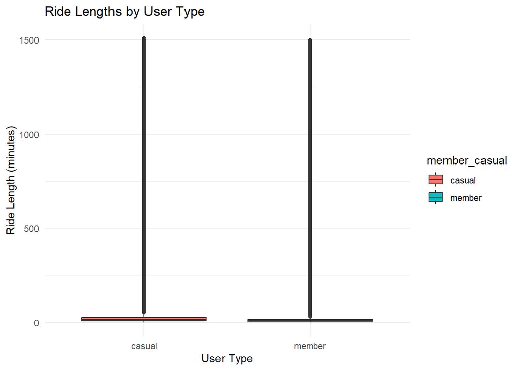

```r
ggplot(cleaned_df,aes(x=member_casual,y=ride_length_seconds/60,fill=member_casual)) +
  geom_boxplot() +
  labs (title = "Ride Lengths by User Type", x = "User Type", y = "Ride Length (minutes)") +
  theme_minimal()
```

### Number of Rides by Day of the Week for Members and Casual Riders

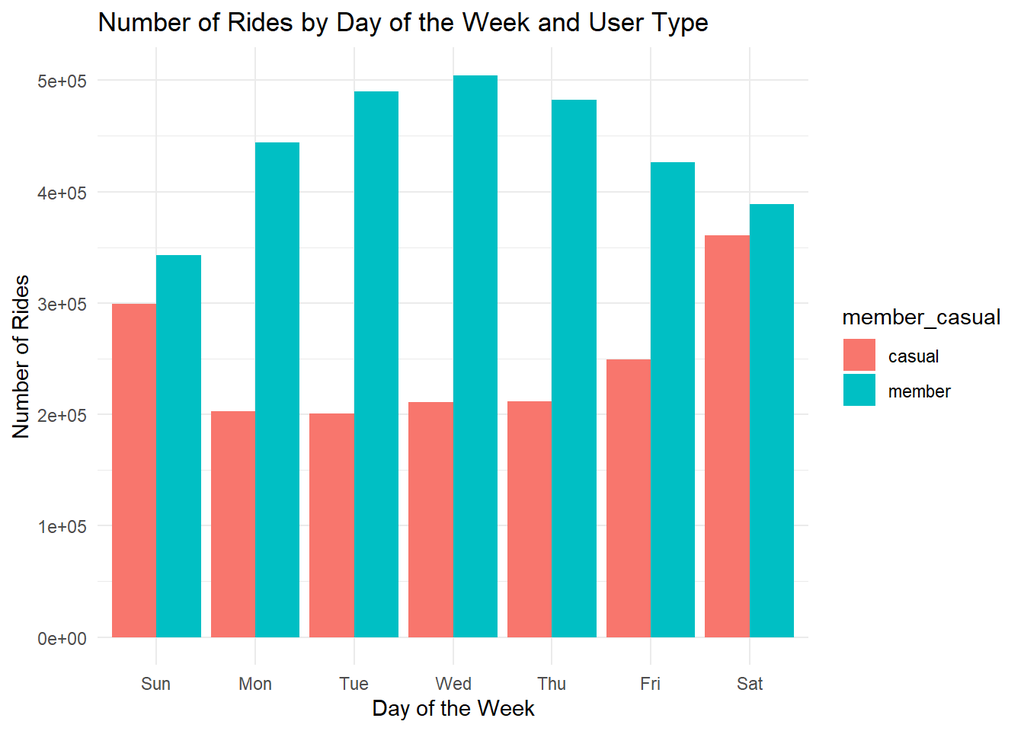

```r
ggplot(cleaned_df, aes(x = week_day, fill = member_casual)) +
  geom_bar(position = "dodge") +
  labs(title = "Number of Rides by Day of the Week and User Type", x = "Day of the Week", y = "Number of Rides") +
  theme_minimal()
```

### Average Ride Length by Day of the Week for Members and Casual Riders:

```r
avg_ride_length_by_day <- cleaned_df %>%
  group_by(week_day, member_casual) %>%
  summarise(average_ride_length = mean(ride_length_seconds, na.rm = TRUE))
```

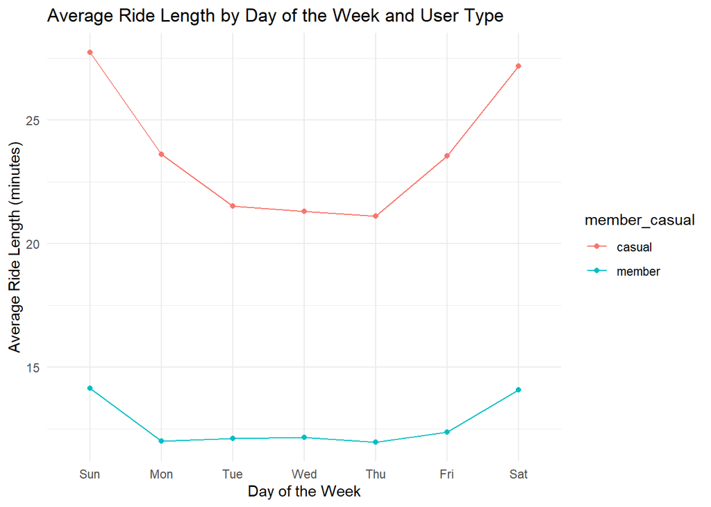

```r
ggplot(avg_ride_length_by_day, aes(x = week_day, y = average_ride_length/60, color = member_casual, group = member_casual)) +
  geom_line() +
  geom_point() +
  labs(title = "Average Ride Length by Day of the Week and User Type", x = "Day of the Week", y = "Average Ride Length (minutes)") +
  theme_minimal()
```

### Total Number of Rides by Month for Members and Casual Riders:

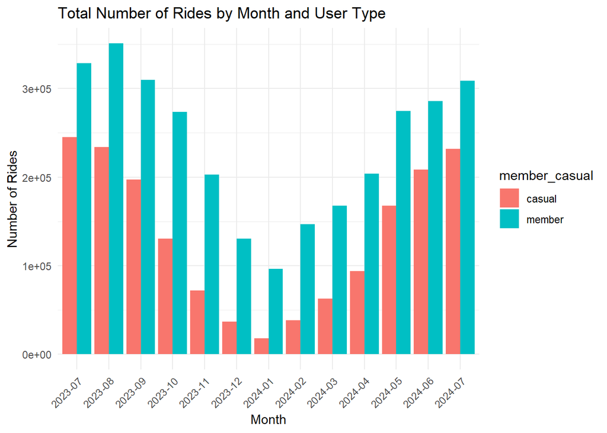

```r
cleaned_df <- cleaned_df %>%
  mutate(month = format(started_at, "%Y-%m"))

ggplot(cleaned_df, aes(x = month, fill = member_casual)) +
  geom_bar(position = "dodge") +
  labs(title = "Total Number of Rides by Month and User Type", x = "Month", y = "Number of Rides") +
  theme_minimal() +
  theme(axis.text.x = element_text(angle = 45, hjust = 1))
```

### Ride Length Distribution for Members and Casual Riders:

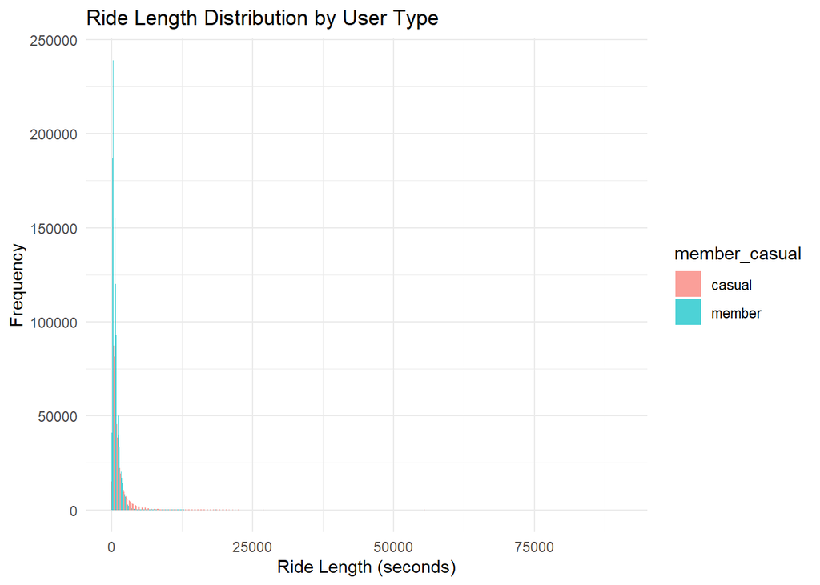

```r
ggplot(cleaned_df, aes(x = ride_length_seconds, fill = member_casual)) +
  geom_histogram(binwidth = 60, position = "dodge", alpha = 0.7) +
  labs(title = "Ride Length Distribution by User Type", x = "Ride Length (seconds)", y = "Frequency") +
  theme_minimal()
```

### Ride Type Usage by Members and Casual Riders:

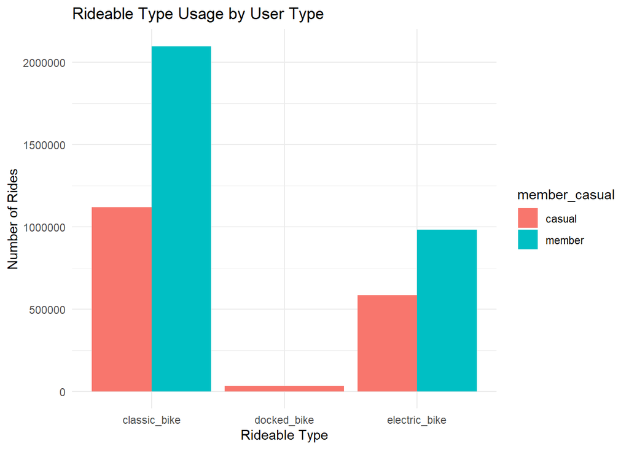

```r
ggplot(cleaned_df, aes(x = rideable_type, fill = member_casual)) +
  geom_bar(position = "dodge") +
  labs(title = "Rideable Type Usage by User Type", x = "Rideable Type", y = "Number of Rides") +
  theme_minimal()
```

### Facet Grid of Ride Lengths by User Type and Day of the Week:

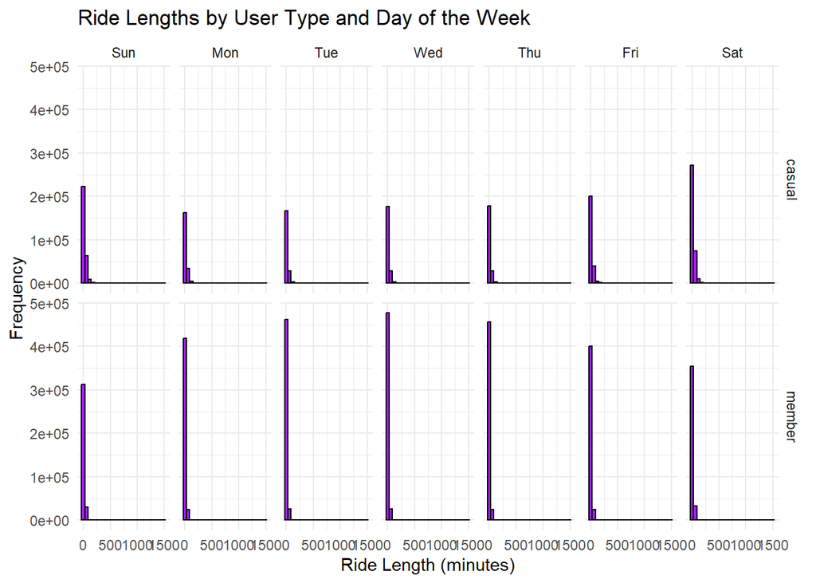

```r
ggplot(cleaned_df, aes(x = ride_length_seconds/60)) +
  geom_histogram(binwidth = 60, fill = "purple", color = "black") +
  facet_grid(member_casual ~ week_day) +
  labs(title = "Ride Lengths by User Type and Day of the Week", x = "Ride Length (minutes)", y = "Frequency") +
  theme_minimal()
```

## Weekly Patterns

- **Most Popular Day**: Saturday, especially among casual riders.
- **Usage Trends**: Casual riders tend to use bikes more on weekends for leisure, while members use them more during weekdays, possibly for commuting.
- **Seasonality**: Ride numbers drop during winter.

## Key Findings

1. **Ride Distribution**: Members have shorter but more frequent rides, while casual riders have longer rides, especially on weekends.
2. **Bike Type Preference**: Classic bikes are the most popular, with electric bikes being used by about half as many riders. Docked bikes are used exclusively by casual riders.
3. **Seasonal Influence**: Ride frequency decreases significantly during winter.

## Recommendations

1. **Introduce a Weekend-Focused Membership Package**: To attract casual riders who primarily ride on weekends.
2. **Targeted Marketing Campaigns**: Focus on weekends to convert casual riders to members.
3. **Promote Electric Bikes**: Increase the promotion of electric bikes to boost their usage among both casual and member riders.